# 03-BFALgtseq-test3

23 January 2023

This is the third test of the primers for the BFAL.

Reminding myself: I used one primer pool, with different concentrations to even out coverage across primers.

## Taking a look at output from GTscore

```r
library(tidyverse)
```

The plot we want is the R1 reads where the FWD primer was found vs. the flashed read where the FWD primer was found.

```r
# read in the GTscore output

flashed <- read_tsv("../data/test3/merged_GTscore_locusSummary.txt") %>%
  select(Locus, `Primer Reads`) %>%
  rename(flashed_reads = `Primer Reads`)
R1 <- read_tsv("../data/test3/R1_GTscore_locusSummary.txt") %>%
  select(Locus, `Primer Reads`) %>%
  rename(R1_reads = `Primer Reads`)
```

Look at those two df combined based on locus

```r
combo_df <- R1 %>%
  left_join(., flashed, by = "Locus")

combo_df %>%
  summarise(sum(R1_reads))
```

| sum(R1_reads) |
| --- |
| 5233394 |

```r
combo_df %>%
  summarise(sum(flashed_reads))
```

| sum(flashed_reads) |
| --- |
| 2074975 |

```r
# how many had 0 reads
combo_df %>%
  filter(R1_reads == 0)
```

| Locus | R1_reads | flashed_reads |
| --- | --- | --- |
| BFAL_scaffold_0_4330405 | 0 | 0 |
| BFAL_scaffold_5_3862639 | 0 | 0 |
| BFAL_scaffold_5_523288 | 0 | 0 |
| BFAL_scaffold_10_1427435 | 0 | 0 |
| BFAL_scaffold_10_2628257 | 0 | 0 |
| BFAL_scaffold_10_3765633 | 0 | 0 |
| BFAL_scaffold_10_3913065 | 0 | 0 |
| BFAL_scaffold_14_2620367 | 0 | 0 |
| BFAL_scaffold_15_1957403 | 0 | 0 |
| BFAL_scaffold_19_1937583 | 0 | 0 |

[output cut: 47 more lines]

57 zeros (we would have expected 60).

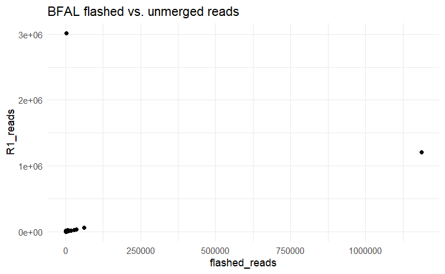

```r
combo_df %>%
  ggplot(aes(x = flashed_reads, y = R1_reads)) +
  geom_point() +
  labs(title = "BFAL flashed vs. unmerged reads") +
  theme_minimal()
```

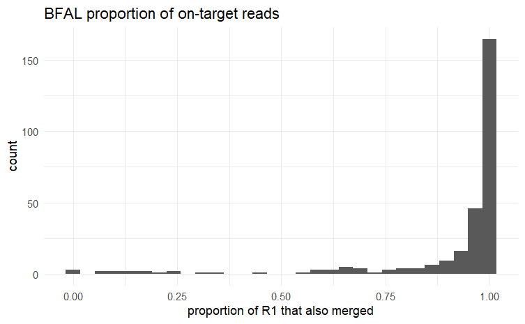

```r
# create a proportion difference
combo_df %>%
  mutate(prop = flashed_reads/R1_reads) %>%
  ggplot(aes(x = prop)) +
  geom_histogram() +
  labs(x = "proportion of R1 that also merged",
       title = "BFAL proportion of on-target reads") +
  theme_minimal()
```

```r
NA
NA
```

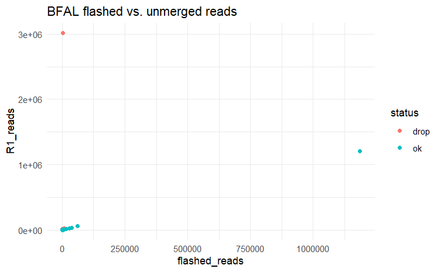

```r
combo_df %>%
  filter(!R1_reads == 0) %>% # these correspond to the 18 loci that I removed based on the first iteration.
  mutate(prop = flashed_reads/R1_reads) %>%
  #filter(prop < 0.75 & R1_reads > 10000) %>% # how many loci with < 75% on-target?
  mutate(status = ifelse(prop < 0.75 & R1_reads >5000, "drop", "ok")) %>%
  ggplot(aes(x = flashed_reads, y = R1_reads, color = status)) +
  geom_point() +
  labs(title = "BFAL flashed vs. unmerged reads") +
  theme_minimal()
```

```r
NA
NA
```

So there are maybe just two obvious loci to drop?

```r
overampers <- combo_df %>%
  filter(R1_reads > 1000000)

overampers
```

| Locus | R1_reads | flashed_reads |
| --- | --- | --- |
| BFAL_scaffold_554_435715 | 3019180 | 3026 |
| BFAL_scaffold_646_455236 | 1207095 | 1186630 |

Look at the plot without those two:

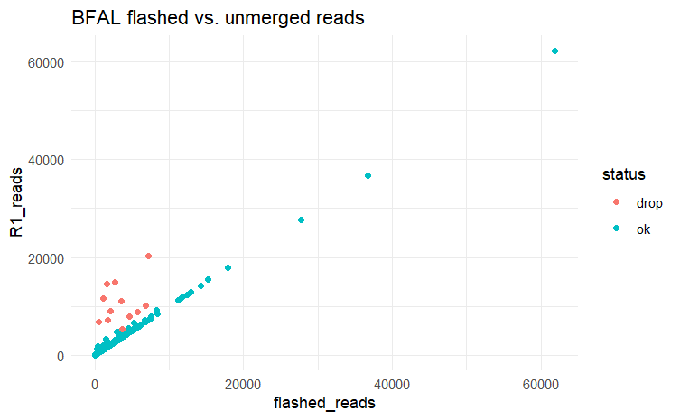

```r
combo_df %>%
  anti_join(., overampers) %>%
   filter(!R1_reads == 0) %>% # these correspond to the 18 loci that I removed based on the first iteration.
  mutate(prop = flashed_reads/R1_reads) %>%
  #filter(prop < 0.75 & R1_reads > 10000) %>% # how many loci with < 75% on-target?
  mutate(status = ifelse(prop < 0.75 & R1_reads >5000, "drop", "ok")) %>%
  ggplot(aes(x = flashed_reads, y = R1_reads, color = status)) +
  geom_point() +
  labs(title = "BFAL flashed vs. unmerged reads") +
  theme_minimal()
```

```r
NA
```

Seems like I could drop more, but they’re not particularly prone to over-amplifying.

One key question: how did the primer concentration tweaking fare?

```r
combo_df %>%
  anti_join(., overampers) %>%
   filter(!R1_reads == 0) %>% # these correspond to the 18 loci that I removed based on the first iteration.
  mutate(prop = flashed_reads/R1_reads) %>%
  #filter(prop < 0.75 & R1_reads > 10000) %>% # how many loci with < 75% on-target?
  mutate(status = ifelse(prop < 0.75, "drop", "ok"))
```

| Locus | R1_reads | flashed_reads | prop | status |
| --- | --- | --- | --- | --- |
| BFAL_scaffold_0_4543438 | 7848 | 7606 | 0.96916412 | ok |
| BFAL_scaffold_1_5556176 | 3799 | 3786 | 0.99657805 | ok |
| BFAL_scaffold_3_875260 | 1157 | 1153 | 0.99654278 | ok |
| BFAL_scaffold_4_4005861 | 341 | 337 | 0.98826979 | ok |
| BFAL_scaffold_5_3710486 | 2478 | 2409 | 0.97215496 | ok |
| BFAL_scaffold_5_697809 | 3675 | 3649 | 0.99292517 | ok |
| BFAL_scaffold_7_15896 | 370 | 368 | 0.99459459 | ok |
| BFAL_scaffold_7_3089859 | 3127 | 3120 | 0.99776143 | ok |
| BFAL_scaffold_7_4109482 | 1467 | 1458 | 0.99386503 | ok |
| BFAL_scaffold_8_2680159 | 753 | 751 | 0.99734396 | ok |

[output cut: 275 more lines]

```r
loc.list <- combo_df %>%
  anti_join(., overampers) %>%
  filter(!R1_reads == 0) %>%
  arrange(R1_reads)
```

284 loci in the primer pool this time (and 285 with reads… hopefully one of the loci with 2 or 3 reads).

```r
test3_primer_conc <- read_csv("csv_outputs/gtseq_test3_primer_cherrypick.csv")
tmp <- test3_primer_conc %>%
  filter(cherrypick_ul == 0)
```

```r
loc.list$Locus <- gsub("BFAL_", "", loc.list$Locus)

loc.list
```

| Locus | R1_reads | flashed_reads |
| --- | --- | --- |
| scaffold_138_1235535 | 2 | 0 |
| scaffold_645_141602 | 3 | 0 |
| scaffold_91_1220718 | 32 | 32 |
| scaffold_289_1045900 | 37 | 2 |
| scaffold_30_2857044 | 41 | 5 |
| scaffold_1180_121024 | 71 | 11 |
| scaffold_40_612943 | 75 | 74 |
| scaffold_273_874676 | 127 | 120 |
| scaffold_582_107987 | 200 | 196 |
| scaffold_183_839619 | 234 | 234 |

[output cut: 275 more lines]

```r
prior_conc_df <- loc.list %>%
  left_join(., test3_primer_conc, by = c("Locus" = "locus")) %>%
  filter(cherrypick_ul != 0)
```

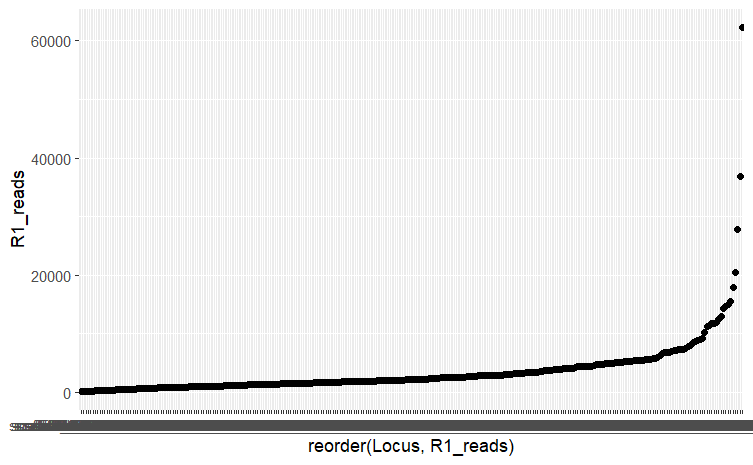

```r
prior_conc_df %>%
  arrange(desc(cherrypick_ul)) %>%
  ggplot() +
  geom_point(aes(x = reorder(Locus, R1_reads), y = R1_reads))
```

Average number of reads, excluding overampers:

```r
loc.list %>%
  summarise(mean(flashed_reads))
```

| mean(flashed_reads) |
| --- |
| 3106.382 |

```r
loc.list %>%
  summarise(median(flashed_reads))
```

| median(flashed_reads) |
| --- |
| 1913 |

```r
NA
```

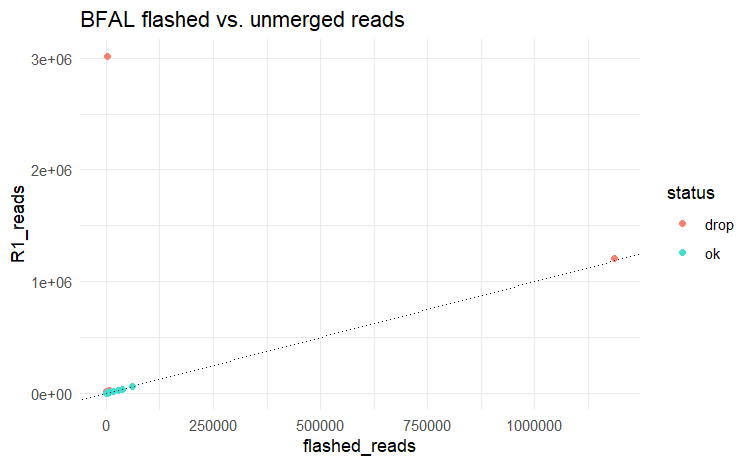

```r
combo_df %>%
  filter(!R1_reads == 0) %>% # these correspond to the loci that I removed based on the first two iterations.
  mutate(prop = flashed_reads/R1_reads) %>%
  #filter(prop < 0.75 & R1_reads > 10000) %>% # how many loci with < 75% on-target?
  mutate(status = ifelse(prop < 0.70 & R1_reads > 3000 | R1_reads > 100000, "drop", "ok")) %>%
  #filter(status != "drop") %>%
  ggplot(aes(x = flashed_reads, y = R1_reads, color = status)) +
  geom_point() +
  scale_color_manual(values = c("salmon", "turquoise")) +
  geom_abline(linetype = "dotted") +
  labs(title = "BFAL flashed vs. unmerged reads") +
  theme_minimal()
```

[output not shown]

[output cut: 24 more lines]

This would be dropping 21 additional loci - mostly because of high off-target issues.

And the plot without droppers?

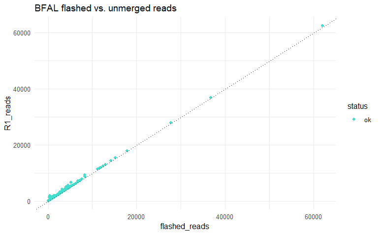

```r
combo_df %>%
  filter(!R1_reads == 0) %>% # these correspond to the loci that I removed based on the first two iterations.
  mutate(prop = flashed_reads/R1_reads) %>%
  #filter(prop < 0.75 & R1_reads > 10000) %>% # how many loci with < 75% on-target?
  mutate(status = ifelse(prop < 0.7 & R1_reads > 2000 | R1_reads > 100000, "drop", "ok")) %>%
  anti_join(., droppers) %>%
  #filter(status != "drop") %>%
  ggplot(aes(x = flashed_reads, y = R1_reads, color = status)) +
  geom_point() +
  scale_color_manual(values = c("turquoise")) +
  geom_abline(linetype = "dotted") +
  labs(title = "BFAL flashed vs. unmerged reads") +
  theme_minimal()
```

Primer concentrations for those keepers?

Here I want to both take into account the # of flashed reads and the cherrypick volume - because we don’t want to bump down primer sets that needed a boost previously.

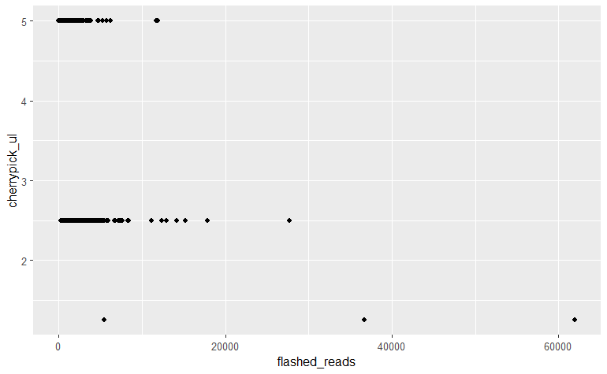

```r
loc.list %>%
  anti_join(., droppers) %>%
  filter(!Locus %in% c("scaffold_222_273845", "scaffold_259_1105854", "scaffold_138_1235535")) %>% # the on-target % looked bad.
  left_join(., prior_conc_df) %>%
  filter(cherrypick_ul != "0") %>%
  arrange(desc(flashed_reads)) %>%
  mutate(read_ul_ratio = flashed_reads/cherrypick_ul) %>%
  arrange(read_ul_ratio) %>%
  #write_csv("csv_outputs/intermed_gtseq_test3_primer_updates.csv")
  ggplot(aes(x = flashed_reads, y = cherrypick_ul)) +
  geom_point()
```

The read/ul ratio indicates how many reads are produced per ul of primer set. In this case, overampers will have a very high ratio and underperformers a low ratio.

I think we can leave 5 ul as the max cherrypick volume and drop everything else relative to that.

For genotyping, in this run, I’d like around 5000 reads/locus (~50 reads per locus/indiv).

```r
conc_tmp <- loc.list %>%
  anti_join(., droppers) %>%
  filter(!R1_reads == 0,
         !Locus %in% c("scaffold_222_273845", "scaffold_259_1105854")) %>% # the on-target % looked bad.
  left_join(., prior_conc_df) %>%
  filter(cherrypick_ul != "0") %>%
  arrange(desc(flashed_reads)) %>%
  mutate(read_ul_ratio = flashed_reads/cherrypick_ul) %>%
  arrange(read_ul_ratio)
# deal with the individual categories separately
conc_tmp %>%
  filter(flashed_reads < 1000, cherrypick_ul > 2.5) %>%
  mutate(new_ul = 5)
```

| Locus | R1_reads | flashed_reads | Plate Name | Well Position | cherrypick_ul | read_ul_ratio | new_ul |
| --- | --- | --- | --- | --- | --- | --- | --- |
| scaffold_289_1045900 | 37 | 2 | BFALgtseqPlate3R | E04 | 5 | 0.4 | 5 |
| scaffold_30_2857044 | 41 | 5 | BFALgtseqPlate1R | A08 | 5 | 1.0 | 5 |
| scaffold_1180_121024 | 71 | 11 | BFALgtseqPlate4R | F06 | 5 | 2.2 | 5 |
| scaffold_91_1220718 | 32 | 32 | BFALgtseqPlate2R | E03 | 5 | 6.4 | 5 |
| scaffold_40_612943 | 75 | 74 | BFALgtseqPlate1R | E09 | 5 | 14.8 | 5 |
| scaffold_273_874676 | 127 | 120 | BFALgtseqPlate3R | G03 | 5 | 24.0 | 5 |
| scaffold_582_107987 | 200 | 196 | BFALgtseqPlate3R | E12 | 5 | 39.2 | 5 |
| scaffold_393_573517 | 1313 | 222 | BFALgtseqPlate3R | A08 | 5 | 44.4 | 5 |
| scaffold_143_1756997 | 291 | 224 | BFALgtseqPlate2R | D07 | 5 | 44.8 | 5 |
| scaffold_183_839619 | 234 | 234 | BFALgtseqPlate2R | E09 | 5 | 46.8 | 5 |

[output cut: 32 more lines]

```r
NA
```

```r
test4_file <- conc_tmp %>%
  mutate(multiplier = ifelse(flashed_reads < 100, 3, NA)) %>%
    mutate(multiplier = ifelse(flashed_reads < 1000 & flashed_reads > 100, 2, multiplier)) %>%
     mutate(multiplier = ifelse(flashed_reads < 5000 & flashed_reads >= 1000, 1.5, multiplier)) %>%
      mutate(multiplier = ifelse(flashed_reads > 5000 & flashed_reads < 10000, 1, multiplier)) %>%
        mutate(multiplier = ifelse(flashed_reads > 10000 & flashed_reads < 60000, 0.5, multiplier)) %>%
           mutate(multiplier = ifelse(flashed_reads > 60000, 0.25, multiplier)) %>%
  mutate(new_ul = round(multiplier*cherrypick_ul/3, digits = 2)) %>% #%>% # make it so the max volume is 5 for any given primer pair
  #summarise(sum(new_ul))
  select(`Plate Name`, `Well Position`, Locus, new_ul)

# make sure there aren't droppers in there...
droppers %>%
  left_join(., test4_file)
```

| Locus | R1_reads | flashed_reads | prop | status | Plate Name | Well Position | new_ul |
| --- | --- | --- | --- | --- | --- | --- | --- |
| BFAL_scaffold_16_3538528 | 11648 | 1145 | 0.098300137 | drop | NA | NA | NA |
| BFAL_scaffold_51_1220763 | 4881 | 3368 | 0.690022536 | drop | NA | NA | NA |
| BFAL_scaffold_65_1335404 | 2273 | 1447 | 0.636603608 | drop | NA | NA | NA |
| BFAL_scaffold_132_1379344 | 2663 | 1705 | 0.640255351 | drop | NA | NA | NA |
| BFAL_scaffold_148_727111 | 10127 | 6805 | 0.671966031 | drop | NA | NA | NA |
| BFAL_scaffold_185_1133045 | 2046 | 1115 | 0.544965787 | drop | NA | NA | NA |
| BFAL_scaffold_185_1182341 | 7193 | 1666 | 0.231614069 | drop | NA | NA | NA |
| BFAL_scaffold_247_950885 | 14645 | 1605 | 0.109593718 | drop | NA | NA | NA |
| BFAL_scaffold_259_1105854 | 14880 | 2669 | 0.179368280 | drop | NA | NA | NA |
| BFAL_scaffold_314_405094 | 7971 | 4587 | 0.575461046 | drop | NA | NA | NA |

[output cut: 11 more lines]

| Plate Name | Well Position | Locus | new_ul |
| --- | --- | --- | --- |
| BFALgtseqPlate3R | E04 | scaffold_289_1045900 | 5.00 |
| BFALgtseqPlate1R | A08 | scaffold_30_2857044 | 5.00 |
| BFALgtseqPlate4R | F06 | scaffold_1180_121024 | 5.00 |
| BFALgtseqPlate2R | E03 | scaffold_91_1220718 | 5.00 |
| BFALgtseqPlate1R | E09 | scaffold_40_612943 | 5.00 |
| BFALgtseqPlate3R | G03 | scaffold_273_874676 | 3.33 |
| BFALgtseqPlate3R | E12 | scaffold_582_107987 | 3.33 |
| BFALgtseqPlate3R | A08 | scaffold_393_573517 | 3.33 |
| BFALgtseqPlate2R | D07 | scaffold_143_1756997 | 3.33 |
| BFALgtseqPlate2R | E09 | scaffold_183_839619 | 3.33 |

[output cut: 270 more lines]

I have too many loci still included. I should be down to the 266 from the filtering steps above.

| Plate Name | Well Position | locus | cherrypick_ul | R1_reads | flashed_reads | prop | status |
| --- | --- | --- | --- | --- | --- | --- | --- |
| BFALgtseqPlate1R | A01 | scaffold_0_4330405 | 0 | NA | NA | NA | NA |
| BFALgtseqPlate1R | C03 | scaffold_10_1427435 | 0 | NA | NA | NA | NA |
| BFALgtseqPlate1R | C04 | scaffold_14_2620367 | 0 | NA | NA | NA | NA |
| BFALgtseqPlate1R | D03 | scaffold_10_2628257 | 0 | NA | NA | NA | NA |
| BFALgtseqPlate1R | D07 | scaffold_27_47556 | 0 | NA | NA | NA | NA |
| BFALgtseqPlate1R | D09 | scaffold_38_1369374 | 0 | NA | NA | NA | NA |
| BFALgtseqPlate1R | D11 | scaffold_56_1120026 | 0 | NA | NA | NA | NA |
| BFALgtseqPlate1R | E03 | scaffold_10_3765633 | 0 | NA | NA | NA | NA |
| BFALgtseqPlate1R | E06 | scaffold_21_3344501 | 0 | NA | NA | NA | NA |
| BFALgtseqPlate1R | E10 | scaffold_48_950302 | 0 | NA | NA | NA | NA |

[output cut: 50 more lines]

| Plate Name | Well Position | Locus | new_ul |
| --- | --- | --- | --- |
| BFALgtseqPlate4R | A01 | scaffold_608_211809 | 0.10 |
| BFALgtseqPlate4R | G02 | scaffold_700_166185 | 0.21 |
| BFALgtseqPlate2R | A02 | scaffold_75_1184494 | 0.42 |
| BFALgtseqPlate1R | C09 | scaffold_37_1483238 | 0.42 |
| BFALgtseqPlate3R | G04 | scaffold_298_460712 | 0.42 |
| BFALgtseqPlate1R | D10 | scaffold_48_3128896 | 0.42 |
| BFALgtseqPlate3R | B09 | scaffold_453_725072 | 0.42 |
| BFALgtseqPlate4R | C05 | scaffold_925_195188 | 0.42 |
| BFALgtseqPlate4R | B07 | scaffold_1273_1937 | 0.42 |
| BFALgtseqPlate4R | H06 | scaffold_1226_115783 | 0.42 |

[output cut: 270 more lines]

Total sum of volume to calculate amount of TE to add:

| sum(new_ul) | TE |
| --- | --- |
| 522.31 | 477.69 |